# The Central Limit Theorem Show!

Alicia Rodriguez  
04/29/2017

### Goal

One of the main concepts in statistics is the well-known **Central Limit Theorem (CLT)**.

It establishes that, given certain conditions, the arithmetic mean of a sufficiently large number of independent random variables, will be approximately normally distributed, regardless of the underlying distribution.

The goal of the application presented is to visually demonstrate this theorem.

### CLT Example

Let's see a small example with an exponential distribution, comparing:

- 1 random variable (1000 samples), with respect to
- the summation of 40 independent random variables (1000 samples each)

```r
set.seed(123456)
expsamples1<-matrix(rexp(rate=0.2, n=1*1000),1000,1)
expsamples40<-matrix(rexp(rate=0.2, n=40*1000),1000,40)

expmean1<-apply(expsamples1, 1, mean)
expmean40<-apply(expsamples40, 1, mean)
```

### CLT Example Plot

Next observe the exponential shape of the 1 random variable (left), and the normal shape of the addition of 40 random variables (right).

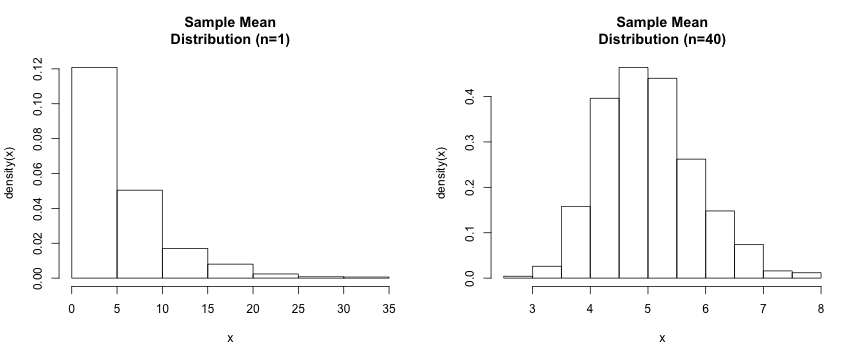

### Try it out yourself!

Go to the app to try this out yourself, testing:

- different distributions (normal, exponential, uniform)
- different number of independent random variables (from 1 to 100)

and observe how each distribution behaves as the number of variables change.

**There is no better way to observe the Central Limit Theorem!**